# Risk

2025-03-07

This is the R markdown (rmd) exercise file that accompanies the lecture notes. It will be your sandbox! Fill in the R code chunks, experiment, and have fun!

# Value at Risk

### Basic Idea

Simulate your P&L data:

```r
PL_simulated <- rnorm(365, mean = 0, sd = 10)
```

Introduction to VaR: https://www.investopedia.com/articles/04/092904.asp

### The Histogram

Estimate the kernel density and plot it over the histogram:

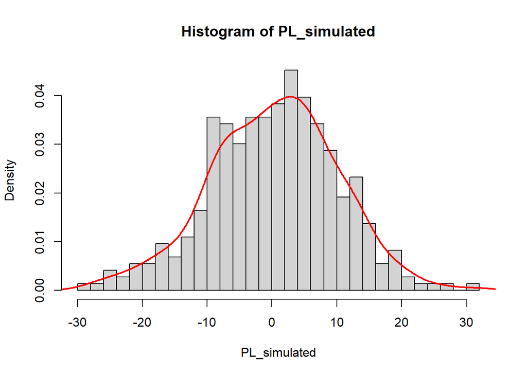

```r
hist(PL_simulated, breaks = 29, freq = FALSE)
lines(density(PL_simulated), col = 'red', lwd = 2)
```

### 5% one-day VaR Calculation

Calculate the 5% one-day VaR for the simulated P&L data:

```r
(quantile_5_percent <- quantile(PL_simulated, prob = 0.05))
```

```
##        5%
## -16.43096
```

```r
(VaR_5_percent <- -quantile_5_percent)
```

```
##       5%
## 16.43096
```

### 1% one-day VaR Calculation

Calculate the 1% one-day VaR for the simulated P&L data:

```r
(quantile_1_percent <- quantile(PL_simulated, prob = 0.01))
```

```
##        1%
## -24.37022
```

```r
(VaR_1_percent <- -quantile_1_percent)
```

```
##       1%
## 24.37022
```

### VaR Given Realized Returns

Pick your own mutual fund for VaR calculation:

http://eoddata.com/stocklist/USMF.htm

### Mutual Fund Data

Download the mutual fund historical prices from Yahoo Finance:

```r
library(quantmod)
symbol <- "BTCRX"
fund.data <- getSymbols(symbol, auto.assign = FALSE, from = "1900-01-01")
```

### Plot the data

Plot the adjusted close:

```r
head(fund.data)
```

```
##            BTCRX.Open BTCRX.High BTCRX.Low BTCRX.Close BTCRX.Volume
## 2024-06-04      23.17      23.17     23.17       23.17            0
## 2024-06-05      23.38      23.38     23.38       23.38            0
## 2024-06-06      23.14      23.14     23.14       23.14            0
## 2024-06-07      22.79      22.79     22.79       22.79            0
## 2024-06-10      22.82      22.82     22.82       22.82            0
## 2024-06-11      22.20      22.20     22.20       22.20            0
##            BTCRX.Adjusted
## 2024-06-04       21.22214
## 2024-06-05       21.41449
## 2024-06-06       21.19466
## 2024-06-07       20.87409
## 2024-06-10       20.90157
## 2024-06-11       20.33369
```

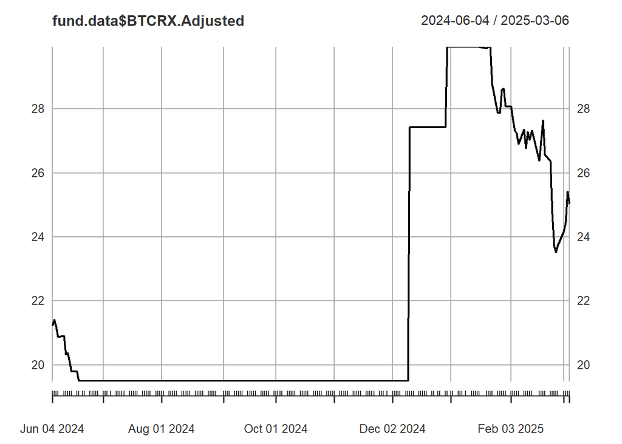

```r
plot(fund.data$BTCRX.Adjusted)
```

### Mutual fund returns

Calculate and plot the mutual fund’s daily returns:

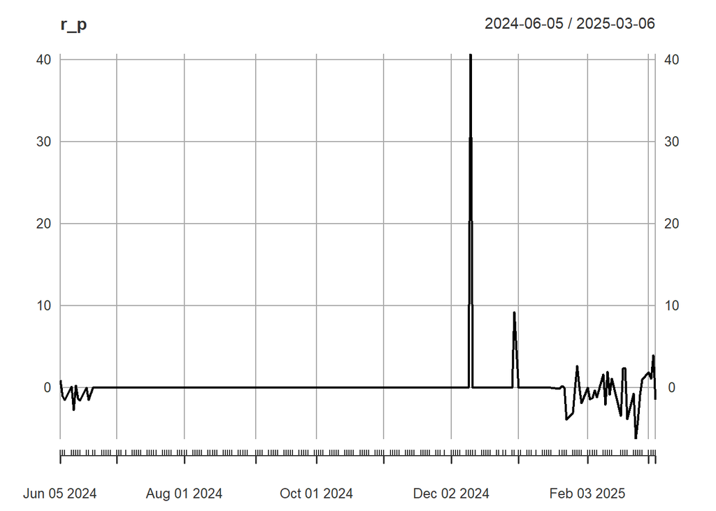

```r
r_p <- Delt(Ad(fund.data)) * 100
r_p <- na.omit(r_p)
names(r_p) <- 'r_p'
plot(r_p)
```

### Summary

Summarize the returns:

```r
summary(r_p)
```

```
##      Index                 r_p
##  Min.   :2024-06-05   Min.   :-6.2571
##  1st Qu.:2024-08-12   1st Qu.: 0.0000
##  Median :2024-10-17   Median : 0.0000
##  Mean   :2024-10-19   Mean   : 0.1297
##  3rd Qu.:2024-12-24   3rd Qu.: 0.0000
##  Max.   :2025-03-06   Max.   :40.6955
```

### Two Methods to Calculate VaR

### Historical VaR

Calculate the historical VaR in percentage terms:

```r
(r_p_quantile_5_percent <- quantile(r_p, prob = 0.05))
```

```
##        5%
## -1.573156
```

```r
(historical_VaR_percentage_terms <- - r_p_quantile_5_percent)
```

```
##       5%
## 1.573156
```

### From Percentage Terms to Dollar Terms

Choose an initial investment, and convert the percentage VaR to dollar VaR:

```r
initial_investment <- 3000
(historical_VaR_dollar_terms <- initial_investment * historical_VaR_percentage_terms / 100)
```

```
##       5%
## 47.19469
```

### The Parametric Approach

Calculate the mean and standard deviation of the returns:

```r
(miu <- mean(r_p))
```

```
## [1] 0.129656
```

```r
(sig <- sd(r_p))
```

```
## [1] 3.209809
```

### VaR Calculation: Finding Quantile

Calculate the quantile for a standard normal distribution:

```r
(z_quantile <- qnorm(0.05))
```

```
## [1] -1.644854
```

### VaR Calculation

Calculate the VaR in percentage terms and in dollar terms:

```r
r_p_quantile <- miu + sig * z_quantile
(normal_VaR_percentage_terms <- -r_p_quantile)
```

```
## [1] 5.15001
```

```r
(normal_VaR_dollar_terms <- initial_investment * normal_VaR_percentage_terms / 100)
```

```
## [1] 154.5003
```

### VaR at different horizon

Calculate mean and standard deviation at the annual horizon:

```r
(miu_annual <- 252 * miu)
```

```
## [1] 32.67332
```

```r
(sig_annual <- sqrt(252) * sig)
```

```
## [1] 50.95414
```

### Annual VaR

Calculate the annual VaR for your investment:

```r
(r_p_annual_quantile <- miu_annual + sig_annual * z_quantile)
```

```
## [1] -51.13878
```

```r
(normal_VaR_annual_percentage_terms <- -r_p_annual_quantile)
```

```
## [1] 51.13878
```

```r
(normal_VaR_annual_dollar_terms <- initial_investment * normal_VaR_annual_percentage_terms / 100)
```

```
## [1] 1534.163
```

Note that we assume 252 trading days in a year: https://en.wikipedia.org/wiki/Trading_day

### Historical VaR versus Parametric VaR

Compare the historical VaR and the parametric (normal) VaR:

```r
historical_VaR_dollar_terms
```

```
##       5%
## 47.19469
```

```r
normal_VaR_dollar_terms
```

```
## [1] 154.5003
```

Plot the histogram and the fitted normal density function to match the mean and standard deviation:

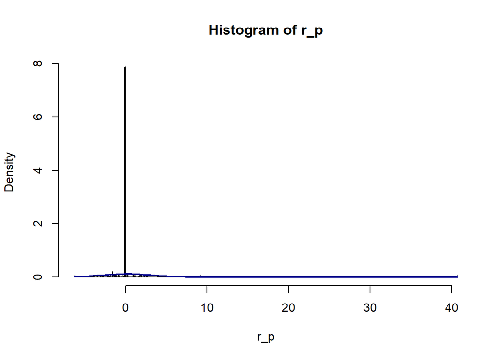

```r
hist(r_p, breaks = 500, freq = FALSE)
curve(dnorm(x, mean = mean(r_p), sd = sd(r_p)),
      add=TRUE, col = "darkblue", lwd = 2)
```

### Probability of Observing Extrem Returns

Calculate the tail probability of observing an extreme return (the minimum return), under the assumption that the return is normally distributed:

```r
(r_p_min <- min(r_p))
```

```
## [1] -6.257116
```

```r
pnorm(r_p_min, mean = miu, sd = sig)
```

```
## [1] 0.0233083
```

# Expected Shortfall

### VaR Shortcomings

VAR versus expected shortfall: https://www.risk.net/risk-magazine/technical-paper/1506669/var-versus-expected-shortfall

### ES calculation

Evalvulate the expected short fall, both in percentage terms and in dollar terms:

```r
left_tail <- r_p[r_p < r_p_quantile_5_percent]
(ES_percentage_terms <- - mean(left_tail))
```

```
## [1] 3.296614
```

```r
(ES_dollar_terms <- initial_investment * ES_percentage_terms/100)
```

```
## [1] 98.89843
```

```r
historical_VaR_dollar_terms
```

```
##       5%
## 47.19469
```